# Biometrie onderzoek

Cheyenne Brouwer (399308), Kasthury Inparajah (462193), Demi van ’t Oever (415069), Willem Daniël Visser(458075)

`24-04-2023`

## Inleiding

Naar aanleiding van een schoolopdracht van de module “De Wetenschapplijke Cyclus” genaamd “Workshop Biometrie” is er een onderzoek uitvoerd met twee biometrische aspecten en hun relatie geanalyseerd. Er is onderzoek gedaan naar de relatie tussen de sexe van de mens en de lengte/breedte ratio van de dominante hand van studenten.

De onderszoeksvraag is: “Is er bij de mens een sexe verschil in de lengte/breedte ratio van de hand?”. Er wordt er vannuit gegaan dat er bij de mens een sexe verschil in de lengte/breedte ratio van de hand.

De nulhypothese luidt dan: “Er is bij de mens geen sexe verschil in de lengte/breedte ratio van de hand.”

De hypothese luidt: “Er is bij de mens een sexe verschil in de lengte/breedte ratio van de hand.”

### Ontwerp van het experiment

#### Protocol voor meting handlengte en handbreedte

##### Benodigdheden

1. Op milimeter nauwkurige meetlat
2. Spreadsheet om resultaten vast te leggen, met toegang hiertoe op locaties zonder internet-toegang
3. Een laborant-ID: een unieke *identifier* per metende onderzoeker
4. Minstens twee metende onderzoekers

##### Data verzamelen

###### Voor het meten van de handlengte

Een metende onderzoeker legt het meetlat op de handen van de studenten met de nulkant op het randje van de middelvinger of het bovenste handstreepje. De andere kant van de meetlat gaat dan richting de andere kant; op het randje van de middelvinger of de bovenste handspreepje. Dan lezen de metende onderzoekers beide de afstand tussen het randje van de middelvinger tot het bovenste handstreepje af en melden dit aan de noterende onderzoekers.

###### Voor het meten van de handbreedte

Een metende onderzoeker legt het meetlat opnieuw op de handen van de studenten met de nulkant op de onderste duimknokkel en de andere kant in de parallele richting van het bovenste handstreepje. De metende onderzoekers lezen beide de afstand tussen de onderste duimknoppel en andere kant van de hand en melden dit aan de noterende onderzoekers.

## Analyse

### Lees je eigen data in

```r
data_file <- "./Biometrie_3.csv"

#data format: laborant_ID,subject_ID,handlengte,handbreedte,sexe
biometric_data <- read.table(file = data_file,
                        header = TRUE,
                        sep = ",")
print(biometric_data)
```

```
##    laborant_id subject_id handlengte handbreedte sexe
## 1         9308       B001        175          98    F
## 2         9308       B002        182         102    M
## 3         9308       B003        168          93    F
## 4         9308       B004        168         106    M
## 5         9308       B005        185         107    M
## 6         9308       B006        189         107    M
## 7         9308       B007        181         112    M
## 8         9308       B008        184         103    M
## 9         9308       B009        187         106    M
## 10        9308       B010        191         109    M
## 11        2193       B011        158          95    F
## 12        2193       B012        176          89    F
## 13        2193       B013        205         106    M
## 14        2193       B014        180          96    F
```

[output cut: 59 more lines]

```r
sort(biometric_data$sexe)
```

```
##  [1] "F" "F" "F" "F" "F" "F" "F" "F" "F" "F" "F" "F" "F" "F" "F" "F" "F" "F" "F"
## [20] "F" "F" "F" "F" "F" "F" "F" "F" "F" "F" "F" "F" "F" "F" "F" "F" "F" "F" "F"
## [39] "M" "M" "M" "M" "M" "M" "M" "M" "M" "M" "M" "M" "M" "M" "M" "M" "M" "M" "M"
## [58] "M" "M" "M" "M" "M" "M" "M" "M" "M" "M" "M" "M" "M" "M" "M" "M"
```

```r
biometric_data$laborant_id <- as.factor(biometric_data$laborant_id)
biometric_data$ratio <- biometric_data$handlengte / biometric_data$handbreedte
head(biometric_data)
```

```
##   laborant_id subject_id handlengte handbreedte sexe    ratio
## 1        9308       B001        175          98    F 1.785714
## 2        9308       B002        182         102    M 1.784314
## 3        9308       B003        168          93    F 1.806452
## 4        9308       B004        168         106    M 1.584906
## 5        9308       B005        185         107    M 1.728972
## 6        9308       B006        189         107    M 1.766355
```

```r
library(plyr)
mu_handlengte <- ddply(
  biometric_data,
  "sexe",
  summarise,
  grp.mean=mean(handlengte))
head(mu_handlengte)
```

```
##   sexe grp.mean
## 1    F 174.4211
## 2    M 188.7143
```

```r
library(plyr)
mu_handbreedte <- ddply(
  biometric_data,
  "sexe",
  summarise,
  grp.mean=mean(handbreedte))
head(mu_handbreedte)
```

```
##   sexe  grp.mean
## 1    F  96.10526
## 2    M 107.80000
```

```r
library(plyr)
mu_ratio <- ddply(
  biometric_data,
  "sexe",
  summarise,
  grp.mean=mean(ratio))
head(mu_ratio)
```

```
##   sexe grp.mean
## 1    F 1.817057
## 2    M 1.754023
```

Let op: als je missende data hebt moet je die specificeren door dit argument toe te voegen: `na.strings = "<jouw NA symbool>"`

### Beschrijvende statistiek

De gemiddelde handlengte bij mannen is 188.7mm, bij vrouwen is dit 174.4mm. De ratio is berekend door handlengte te delen door handbreedte. Bij mannen is de ratio 1.75, terwijl deze bij vrouwen 1.81 is.

### Welke verdeling?

Hoe kleiner de steekproefgrootte (*sample size*) hoe lastiger het is de onderliggende verdeling vast te stellen. Speel maar eens met dit blokje code, en verander de steekproefgrootte (`n=`) in de `rnorm()` functie en de `breaks=` in de `hist()` functie. Neem voor *n* bijvoorbeeld achtereenvolgens 10, 100, 1000, 10000, 10000 en voor *breaks* 5, 10, 50. Wanneer zie je een echte normaalverdeling verschijnen?

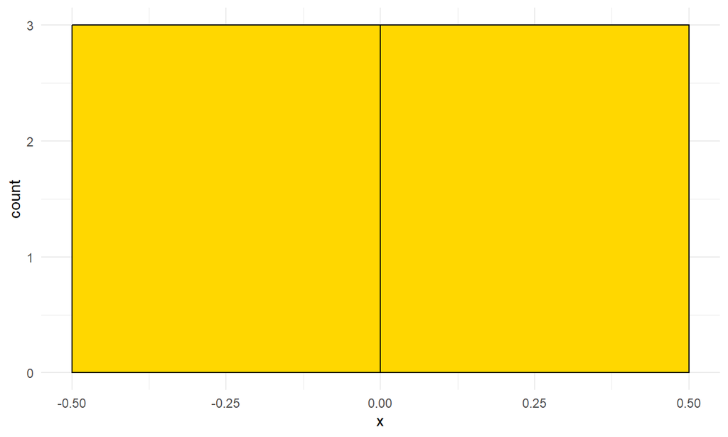

```r
hist_data <- data.frame(
  x = rnorm(
    n = 10
  )
)
ggplot(
  data = hist_data,
  mapping = aes(
    x = x
  )
) + geom_histogram(
  bins=10,
  breaks=c(-0.5, 0, 0.5),
  fill = "gold",
  colour = "black",
) + theme_minimal()
```

**Dit *experiment* met de argumenten van `rnorm()` en `hist()` moet je opnemen in je eigen RMarkdown.**  
Beantwoord deze vragen:

1. Wat gebeurt er met de vorm van de verdeling als `n` groter wordt? -> Als “n”, dus het aantal waarnemingen groter wordt verandert de vorm van de verdeling langzamerhand in een normaal verdeling. De normaal verdeling is een klokvormig figuur. Bij 10000 is de histogram parallel gelijk, splitsend bij x=0, ook is de histogram consistenter in de verdeling van de `n` waarden op de balken. Als ik `n` op 10 zet veranderd de verdeling elke keer.
2. Wat gebeurt er met de spreiding van de data (x-as) als `n` groter wordt, en kan je dat verklaren?

   -> Als de “n” groter wordt, verkleind de spreiding van de data op de x-as. Dit komt doordat de steekproefgemiddelden (gemiddelde van de waarde van “n”) betrouwbaarder worden als “n” groter wordt en dichterbij het werkelijke populatiegemiddelde komen. Hierdoor is er minder variatie op de x-as, omdat de resultaten die worden gemeten hetzelfde of bijna hetzelfde zijn.
3. Waarom is bij zelfde instellingen voor `n` en `breaks` de uitkomst toch verschillend?

   -> De uitkomst van het histogram kan variëren bij de “breaks” argument. Zelfs als de instellingen voor “n” en “break” hetzelfde zijn. Dit komt doordat het argument “breaks” een optionele parameter is en R soms automatisch de verdeling van de gegevens kan aanpassen. Als er wel een waarde wordt opgegeven voor “breaks” zal R deze waarde aanhouden. Het overschrijft dus alle andere instellingen over de horizontale verdeling, de documentatie medlt: “overrides `binwidth`, `bins`, `center`, and `boundary`”.

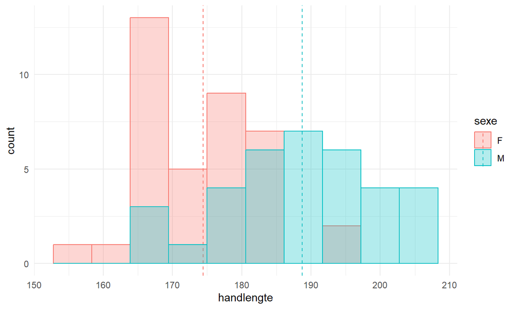

```r
ggplot(
  data = biometric_data,
  mapping = aes(
    x = handlengte,
    color=sexe,
    fill=sexe)
) + geom_vline(
      data=mu_handlengte,
      aes(
        xintercept=grp.mean,
        color=sexe),
      linetype="dashed"
) + geom_histogram(
  bins = 10,
  alpha=0.3,
  position="identity"
) + theme_minimal()
```

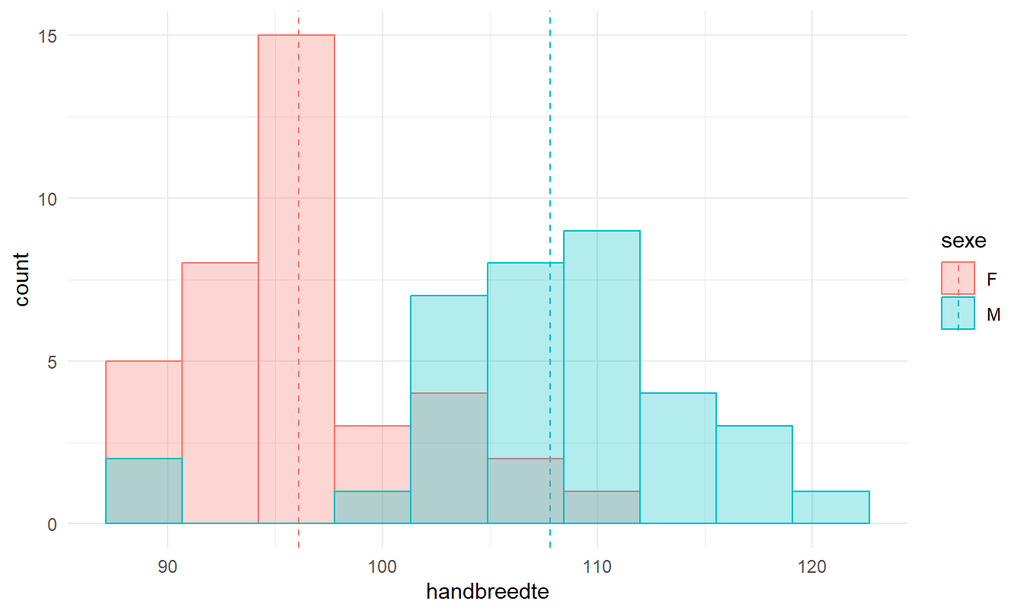

```r
ggplot(
  data = biometric_data,
  mapping = aes(
    x = handbreedte,
    color=sexe,
    fill=sexe)
) + geom_vline(
      data=mu_handbreedte,
      aes(
        xintercept=grp.mean,
        color=sexe),
      linetype="dashed"
) + geom_histogram(
  bins = 10,
  alpha=0.3,
  position="identity"
) + theme_minimal()
```

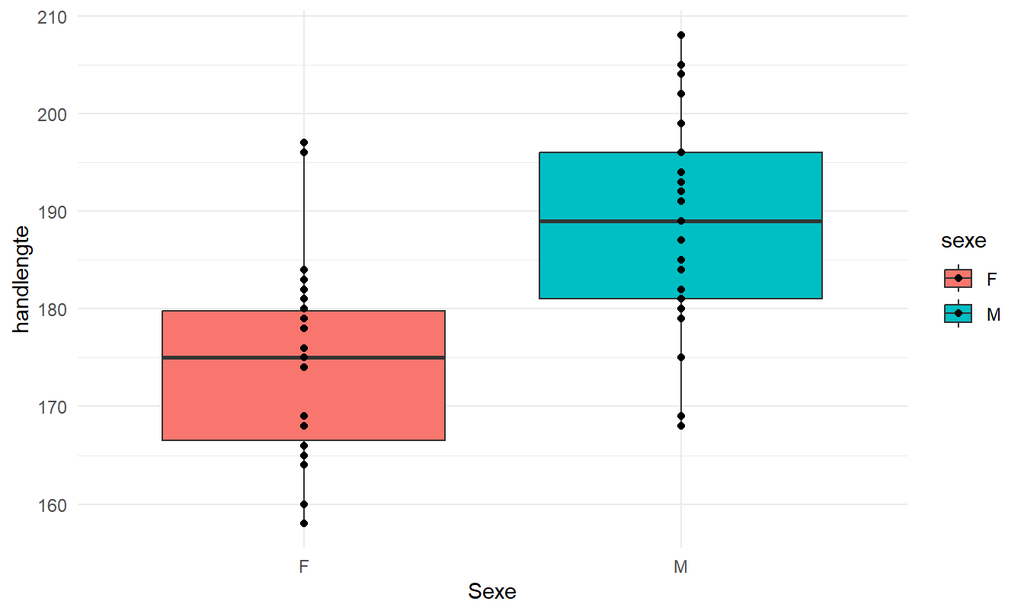

```r
library(ggplot2)
ggplot(data = biometric_data,
       mapping = aes(x = sexe, y = handlengte, fill = sexe)) +
    geom_boxplot() +
    geom_point() +
    labs(x = "Sexe", y = "handlengte") +
    theme_minimal()
```

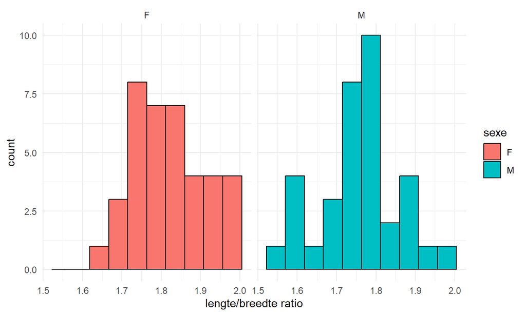

```r
ggplot(data = biometric_data,
       mapping = aes(x = ratio, fill = sexe)) +
    geom_histogram(bins = 10, colour = "black") +
    facet_wrap(. ~ sexe) +
    labs(x = "lengte/breedte ratio") +
    theme_minimal()
```

Bij de mannen is de handlengte symmetrisch verdeeld. Het gemiddelde en de mediaan vallen hierbij samen.

Bij de vrouwen is de handlengte meertoppig verdeeld. Het gemiddelde en de mediaan liggen dus tussen de toppen. Bij deze verdeling is de standaardafwijking relatief groot.

Bij de mannen en vrouwen samen is de handlengte meertoppig verdeeld. Hierbij liggen dus ook het gemiddelde en de mediaan tussen de toppen en is de standaardafwijking ook relatief groot.

Bij de mannen is de handbreedte net als de handlengte symmetrisch verdeeld. Het gemiddelde en de mediaan vallen samen.

Bij de vrouwen is de handbreedte ook net als de handlengte meertoppig verdeeld. Het gemiddelde en de mediaan liggen dus tussen de toppen en de standaardafwijking is relatief groot.

### Bronnen van variatie

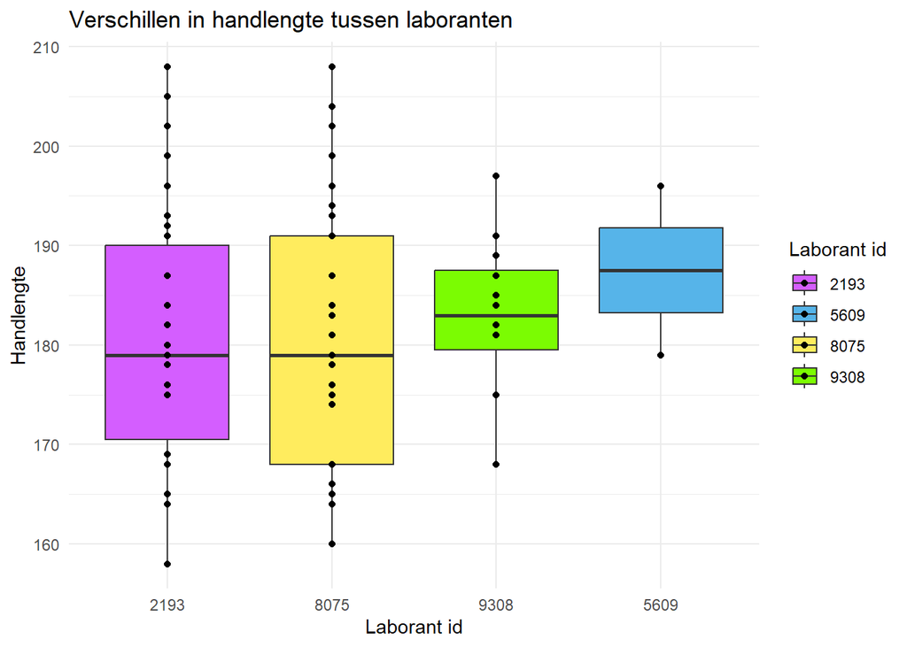

```r
ggplot(
  data = biometric_data,
  mapping = aes(
    x = reorder(laborant_id, handlengte),
    y = handlengte,
    fill = laborant_id)
) +
geom_boxplot() +
geom_point() +
scale_fill_manual(values=c("#d45eff", "#56B4E9", "#ffec5e", "#7bfc02"))+
labs(
  x = "Laborant id",
  y = "Handlengte",
  title="Verschillen in handlengte tussen laboranten"
) +
guides(fill=guide_legend(title="Laborant id")) +
theme_minimal()
```

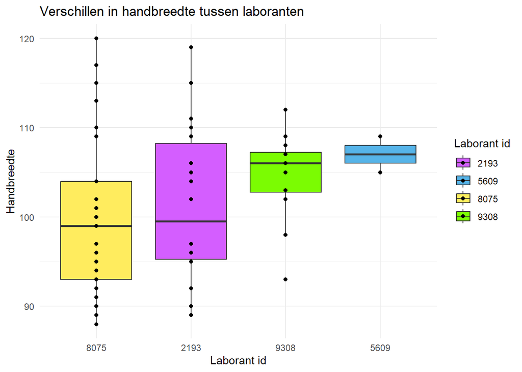

```r
ggplot(
    data = biometric_data,
    mapping = aes(
      x = reorder(laborant_id, handbreedte),
      y = handbreedte,
      fill = laborant_id
    )
) +
geom_boxplot() +
geom_point() +
scale_fill_manual(values=c("#d45eff", "#56B4E9", "#ffec5e", "#7bfc02"))+
labs(
  x = "Laborant id",
  y = "Handbreedte",
  title="Verschillen in handbreedte tussen laboranten"
) +
guides(fill=guide_legend(title="Laborant id")) +
theme_minimal()
```

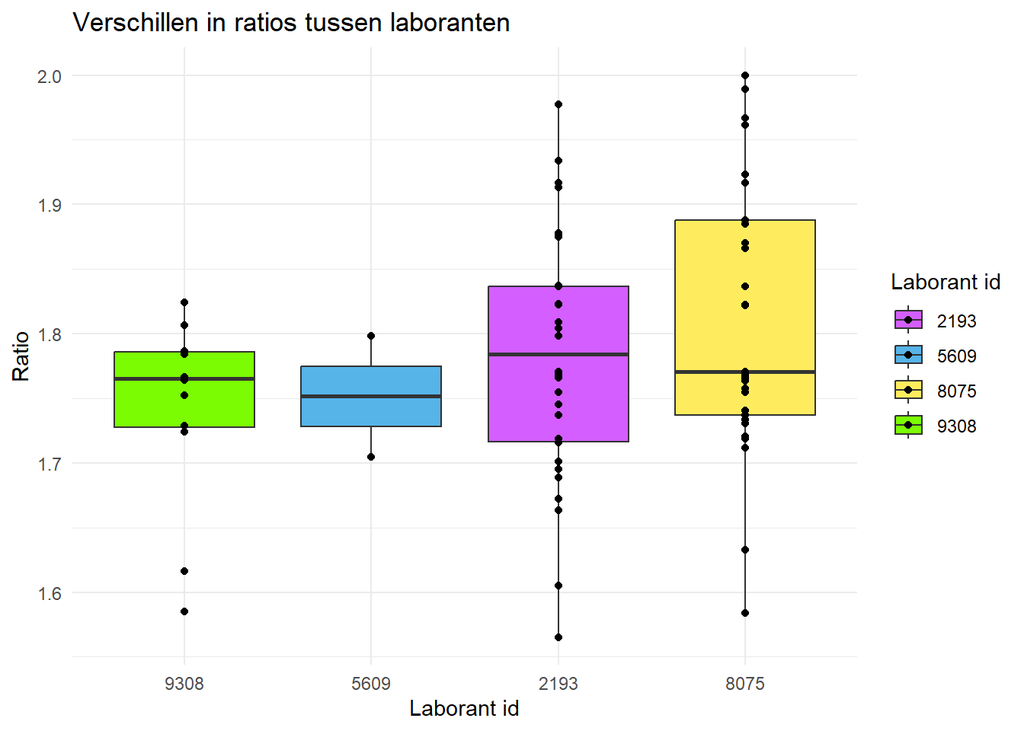

```r
ggplot(
  data = biometric_data,
  mapping = aes(
    x = reorder(laborant_id, ratio),
    y = ratio,
    fill = laborant_id
  )
) +
geom_boxplot() +
geom_point() +
scale_fill_manual(
  values=c("#d45eff", "#56B4E9", "#ffec5e", "#7bfc02"),
) +
labs(
  x = "Laborant id",
  y = "Ratio",
  title="Verschillen in ratios tussen laboranten"
) +
guides(fill=guide_legend(title="Laborant id")) +
theme_minimal()
```

De bronnen van biologische variatie die ten grondslag liggen aan het verschil in handlengte tussen mannen en vrouwen, zowel als respectievelijk voor mannen en respectievelijk voor vrouwen, zijn de omgeving en overerving. De omgeving kan namelijk inspelen op het werk wat mensen doen. Hierin zullen mensen met fysiek zwaar werk meer kans hebben op een grotere handlengte dan mensen die geen fysiek zwaar werk verrichten. In verhouding zal dit verschil tussen mannen en vrouwen groter zijn dan het verschil tussen mannen en vrouwen respectievelijk.

Overerving is ook een bron van biologische variatie die ten grondslag ligt aan het verschil in handlengte tussen mannen en vrouwen, omdat de kans groter is dat iemand grotere handen heeft als dat patroon terug te zien is in de familie. Bij mannen is er een aanleg voor een grotere handlengte en handbreedte, waar vrouwen in verhouding een aanleg hebben voor een kleinere handlengte en handbreedte.

### De hypothese aannemen?

```r
shapiro.test(biometric_data$ratio)
```

```
##
##  Shapiro-Wilk normality test
##
## data:  biometric_data$ratio
## W = 0.98271, p-value = 0.417
```

```r
female_ratios <- subset(biometric_data,
                        subset = sexe == "F",
                        select = ratio,
                        drop = T)
male_ratios <- subset(biometric_data,
                        subset = sexe == "M",
                        select = ratio,
                        drop = T)
t.test(female_ratios, male_ratios)
```

```
##
##  Welch Two Sample t-test
##
## data:  female_ratios and male_ratios
## t = 2.8702, df = 68.695, p-value = 0.005448
## alternative hypothesis: true difference in means is not equal to 0
## 95 percent confidence interval:
##  0.01921769 0.10684932
## sample estimates:
## mean of x mean of y
##  1.817057  1.754023
```

Als eerste is de Shapiro-Wilk test uitgevoerd. Deze test is bedoeld om te onderzoeken of er sprake is van een normale verdeling. Wanneer de p-waarde kleiner is dan 0.05, is er geen sprake van een normale verdeling. Onze p-waarde is 0.417. Deze valt boven de 0.05, waardoor er sprake is van een normale verdeling.

Omdat er sprake is van een normale verdeling, kan er een onafhankelijkte t-test uitgevoerd worden in plaats van een Mann-Whitney U test. De t-test kan gebruikt worden om de nulhypothese te kunnen aannemen of verworpen. Bij de t-test is een p waarde 0.005448 gevonden, wat inhoudt dat de nulhypothese verworpen wordt. De hypothese wordt daardoor aangenomen.

## Reflectie op het experiment

Bespreek in je groep de volgende vragen en voeg de antwoorden toe aan je uitgewerkte onderzoeksdocument.

1. Zijn de metingen tussen de verschillende meters ook (significant) verschillend? Zo ja, waardoor zou je de verschillen kunnen verklaren?

```r
laborant1_metingen <- subset(biometric_data,
                        subset = laborant_id == "8075",
                        select = ratio,
                        drop = T)
laborant2_metingen <- subset(biometric_data,
                        subset = laborant_id == "2193",
                        select = ratio,
                        drop = T)
t.test(laborant1_metingen, laborant2_metingen)
```

```
##
##  Welch Two Sample t-test
##
## data:  laborant1_metingen and laborant2_metingen
## t = 1.0656, df = 56.332, p-value = 0.2912
## alternative hypothesis: true difference in means is not equal to 0
## 95 percent confidence interval:
##  -0.02477312  0.08109262
## sample estimates:
## mean of x mean of y
##  1.811141  1.782981
```

2. Onderzoek de verschillen tussen mannen en vrouwen met betrekking tot hand lengte, handbreedte en de ratio.

Onderstaand staan de uitkomsten van het gemiddelde van de handbreedte, de handlengte en de ratio. Handlengte gemiddelde M – 188,7143 F – 174,4211

Handbreedte gemiddelde M – 107,8 F – 96,10526

Ratio gemiddelde M – 1,754023 F – 1,817057

3. Zou je het protocol aanpassen na deze ervaring, of was hij voldoende duidelijk en reproduceerbaar?

Het protocol was niet duidelijk te volgen, maar wel voldoende reproduceerbaar na feedback van de docent. In de opdracht staat dat er groepen van 2 - 4 personen gemaakt moeten worden. In ons geval werd dit een groep van 4 personen. In het protocol staat vervolgens geschreven: “Wissel de metingen af tussen de verschillende studenten in jouw groepje”. Dit is door ons geïnterpreteerd als: laat elke analist een x aantal proefpersonen meten. Volgens ons stond er niet voldoende duidelijk in het protocol dat het de bedoeling was dat elke proefpersoon onafhankelijk door twee analisten gemeten zou worden.

#### Wat je moet inleveren

Voor de verwerking en analyse van je eigen data maak je gebruik van het aangeleverde template RMarkdown document. Daarin doorloop je dezelfde onderzoek stappen als hieronder, maar dan met je eigen data. Aan het einde van de dag gaat dat document, in originele en “geknitte” vorm, samen met je databestand, in een git repo die is opgezet volgens voorschift in de cursushandleiding. De link hiernaar toe gaat in je portfolio op eJournal. Let op dat je *alle* stappen hebt doorlopen voordat je inlevert. Gebruik ook de RStudio spellingscontrole!  
Vergeet niet jullie namen en studentnummers bovenaan de markdown te zetten!